# UHURU Data set visualization

Anita Dhillon

2023-02-23

The working directory inside this Rmarkdown chunk r chunk is the following:

```r
getwd()
```

```
## [1] "/Users/anitadhillon/Desktop/Spring2023Bio195/Documents"
```

Note: remeber that working directories in a project and an R chunk are not always the same!

## 1. Describing the working data set

UHURU data set

[figure not shown]

## 2. Reading the data set

We are reading a data set in TSV format. This is a “tab separated values” dfiles. To read it into R we use the function read.csv with the `sep =` argument set to `"\t"` which represents a tab in computer language

```r
 read.csv(file = "../data-raw/ACACIA_DREPANOLOBIUM_SURVEY.txt", sep = "\t")
```

| SURVEY | YEAR | SITE | BLOCK | TREATMENT | PLOT | ID | HEIGHT | AXIS1 | AXIS2 | CIRC | FLOWERS | BUDS | FRUITS | ANT |
| --- | --- | --- | --- | --- | --- | --- | --- | --- | --- | --- | --- | --- | --- | --- |
| 1 | 2012 | SOUTH | 1 | TOTAL | S1TOTAL | 581 | 2.25 | 2.75 | 2.15 | 20.0 | 0 | 0 | 10 | CS |
| 1 | 2012 | SOUTH | 1 | TOTAL | S1TOTAL | 582 | 2.65 | 4.10 | 3.90 | 28.0 | 0 | 0 | 150 | TP |
| 1 | 2012 | SOUTH | 1 | TOTAL | S1TOTAL | 3111 | 1.5 | 1.70 | 0.85 | 17.0 | 2 | 1 | 50 | TP |
| 1 | 2012 | SOUTH | 1 | TOTAL | S1TOTAL | 3112 | 2.01 | 1.80 | 1.60 | 12.0 | 0 | 0 | 75 | CS |
| 1 | 2012 | SOUTH | 1 | TOTAL | S1TOTAL | 3113 | 1.75 | 1.84 | 1.42 | 13.0 | 0 | 0 | 20 | CS |
| 1 | 2012 | SOUTH | 1 | TOTAL | S1TOTAL | 3114 | 1.65 | 1.62 | 0.85 | 15.0 | 0 | 0 | 0 | E |
| 1 | 2012 | SOUTH | 1 | TOTAL | S1TOTAL | 3115 | 1.2 | 1.95 | 0.90 | 9.0 | 0 | 0 | 0 | CS |
| 1 | 2012 | SOUTH | 1 | TOTAL | S1TOTAL | 3199 | 1.45 | 2.00 | 1.75 | 12.2 | 0 | 0 | 25 | CS |
| 1 | 2012 | SOUTH | 1 | MESO | S1MESO | 941 | 1.87 | 2.15 | 1.82 | 13.0 | 0 | 0 | 0 | TP |
| 1 | 2012 | SOUTH | 1 | MESO | S1MESO | 942 | 2.38 | 5.55 | 4.82 | 35.0 | 0 | 0 | 50 | TP |

[output cut: 147 more lines]

Assign the data to a variable so we can work with it

```r
acacia <- read.csv(file = "../data-raw/ACACIA_DREPANOLOBIUM_SURVEY.txt", sep = "\t")
```

### 3. Accessing elements of a ‘data.frame’

It is similiar to what we do for vetors, but we have two dimensions

```r
acacia[,6]
```

```
##   [1] "S1TOTAL" "S1TOTAL" "S1TOTAL" "S1TOTAL" "S1TOTAL" "S1TOTAL" "S1TOTAL"
##   [8] "S1TOTAL" "S1MESO"  "S1MESO"  "S1MESO"  "S1MESO"  "S1MESO"  "S1MESO"
##  [15] "S1MESO"  "S1MESO"  "S1MESO"  "S1MESO"  "S1MESO"  "S1MESO"  "S2OPEN"
##  [22] "S2TOTAL" "S2TOTAL" "S2TOTAL" "S2TOTAL" "S2TOTAL" "S2TOTAL" "S2TOTAL"
##  [29] "S2TOTAL" "S2TOTAL" "S2TOTAL" "S2TOTAL" "S2TOTAL" "S2TOTAL" "S2TOTAL"
##  [36] "S2TOTAL" "S2TOTAL" "S2TOTAL" "S2TOTAL" "S2TOTAL" "S2TOTAL" "S2TOTAL"
##  [43] "S2TOTAL" "S2TOTAL" "S2TOTAL" "S2TOTAL" "S2TOTAL" "S2TOTAL" "S2TOTAL"
##  [50] "S2TOTAL" "S2TOTAL" "S2TOTAL" "S2TOTAL" "S2TOTAL" "S2TOTAL" "S2TOTAL"
##  [57] "S2TOTAL" "S2TOTAL" "S2TOTAL" "S2TOTAL" "S2TOTAL" "S2TOTAL" "S2TOTAL"
##  [64] "S2TOTAL" "S2TOTAL" "S2TOTAL" "S2TOTAL" "S2TOTAL" "S2TOTAL" "S2TOTAL"
##  [71] "S2TOTAL" "S2TOTAL" "S2TOTAL" "S2TOTAL" "S2TOTAL" "S2TOTAL" "S2TOTAL"
##  [78] "S2TOTAL" "S2TOTAL" "S2TOTAL" "S2TOTAL" "S2TOTAL" "S2TOTAL" "S2TOTAL"
##  [85] "S2TOTAL" "S2TOTAL" "S2TOTAL" "S2TOTAL" "S2TOTAL" "S2TOTAL" "S2TOTAL"
##  [92] "S2TOTAL" "S2TOTAL" "S2TOTAL" "S2TOTAL" "S2TOTAL" "S2TOTAL" "S2TOTAL"
##  [99] "S2TOTAL" "S2TOTAL" "S2TOTAL" "S2TOTAL" "S2TOTAL" "S2TOTAL" "S2TOTAL"
## [106] "S2TOTAL" "S2TOTAL" "S2MEGA"  "S2MEGA"  "S2MEGA"  "S2MEGA"  "S2MEGA"
## [113] "S2MEGA"  "S2MEGA"  "S2MEGA"  "S2MEGA"  "S2MEGA"  "S2MEGA"  "S2MEGA"
## [120] "S2MEGA"  "S2MESO"  "S2MESO"  "S2MESO"  "S3OPEN"  "S3OPEN"  "S3TOTAL"
## [127] "S3TOTAL" "S3TOTAL" "S3TOTAL" "S3TOTAL" "S3TOTAL" "S3TOTAL" "S3TOTAL"
## [134] "S3TOTAL" "S3TOTAL" "S3TOTAL" "S3TOTAL" "S3TOTAL" "S3TOTAL" "S3TOTAL"
## [141] "S3TOTAL" "S3TOTAL" "S3TOTAL" "S3TOTAL" "S3TOTAL" "S3TOTAL" "S3TOTAL"
## [148] "S3TOTAL" "S3TOTAL" "S3TOTAL" "S3TOTAL" "S3TOTAL" "S3TOTAL" "S3TOTAL"
## [155] "S3TOTAL" "S3MESO"  "S3MESO"
```

```r
str(acacia)
```

```
## 'data.frame':    157 obs. of  15 variables:
##  $ SURVEY   : int  1 1 1 1 1 1 1 1 1 1 ...
##  $ YEAR     : int  2012 2012 2012 2012 2012 2012 2012 2012 2012 2012 ...
##  $ SITE     : chr  "SOUTH" "SOUTH" "SOUTH" "SOUTH" ...
##  $ BLOCK    : int  1 1 1 1 1 1 1 1 1 1 ...
##  $ TREATMENT: chr  "TOTAL" "TOTAL" "TOTAL" "TOTAL" ...
##  $ PLOT     : chr  "S1TOTAL" "S1TOTAL" "S1TOTAL" "S1TOTAL" ...
##  $ ID       : int  581 582 3111 3112 3113 3114 3115 3199 941 942 ...
##  $ HEIGHT   : chr  "2.25" "2.65" "1.5" "2.01" ...
##  $ AXIS1    : num  2.75 4.1 1.7 1.8 1.84 1.62 1.95 2 2.15 5.55 ...
##  $ AXIS2    : num  2.15 3.9 0.85 1.6 1.42 0.85 0.9 1.75 1.82 4.82 ...
##  $ CIRC     : num  20 28 17 12 13 15 9 12.2 13 35 ...
##  $ FLOWERS  : int  0 0 2 0 0 0 0 0 0 0 ...
##  $ BUDS     : int  0 0 1 0 0 0 0 0 0 0 ...
##  $ FRUITS   : int  10 150 50 75 20 0 0 25 0 50 ...
##  $ ANT      : chr  "CS" "TP" "TP" "CS" ...
```

```r
1:100
```

```
##   [1]   1   2   3   4   5   6   7   8   9  10  11  12  13  14  15  16  17  18
##  [19]  19  20  21  22  23  24  25  26  27  28  29  30  31  32  33  34  35  36
##  [37]  37  38  39  40  41  42  43  44  45  46  47  48  49  50  51  52  53  54
##  [55]  55  56  57  58  59  60  61  62  63  64  65  66  67  68  69  70  71  72
##  [73]  73  74  75  76  77  78  79  80  81  82  83  84  85  86  87  88  89  90
##  [91]  91  92  93  94  95  96  97  98  99 100
```

All the following are different ways of accessing certain points in dead

```r
numbers <- 1:10
numbers
```

```
##  [1]  1  2  3  4  5  6  7  8  9 10
```

```r
numbers [3:6]
```

```
## [1] 3 4 5 6
```

```r
numbers[c(1,5,7,3)]
```

```
## [1] 1 5 7 3
```

```r
acacia$SURVEY
```

```
##   [1] 1 1 1 1 1 1 1 1 1 1 1 1 1 1 1 1 1 1 1 1 1 1 1 1 1 1 1 1 1 1 1 1 1 1 1 1 1
##  [38] 1 1 1 1 1 1 1 1 1 1 1 1 1 1 1 1 1 1 1 1 1 1 1 1 1 1 1 1 1 1 1 1 1 1 1 1 1
##  [75] 1 1 1 1 1 1 1 1 1 1 1 1 1 1 1 1 1 1 1 1 1 1 1 1 1 1 1 1 1 1 1 1 1 1 1 1 1
## [112] 1 1 1 1 1 1 1 1 1 1 1 1 1 1 1 1 1 1 1 1 1 1 1 1 1 1 1 1 1 1 1 1 1 1 1 1 1
## [149] 1 1 1 1 1 1 1 1 1
```

```r
acacia[,1]
```

```
##   [1] 1 1 1 1 1 1 1 1 1 1 1 1 1 1 1 1 1 1 1 1 1 1 1 1 1 1 1 1 1 1 1 1 1 1 1 1 1
##  [38] 1 1 1 1 1 1 1 1 1 1 1 1 1 1 1 1 1 1 1 1 1 1 1 1 1 1 1 1 1 1 1 1 1 1 1 1 1
##  [75] 1 1 1 1 1 1 1 1 1 1 1 1 1 1 1 1 1 1 1 1 1 1 1 1 1 1 1 1 1 1 1 1 1 1 1 1 1
## [112] 1 1 1 1 1 1 1 1 1 1 1 1 1 1 1 1 1 1 1 1 1 1 1 1 1 1 1 1 1 1 1 1 1 1 1 1 1
## [149] 1 1 1 1 1 1 1 1 1
```

```r
acacia[,"SURVEY"]
```

```
##   [1] 1 1 1 1 1 1 1 1 1 1 1 1 1 1 1 1 1 1 1 1 1 1 1 1 1 1 1 1 1 1 1 1 1 1 1 1 1
##  [38] 1 1 1 1 1 1 1 1 1 1 1 1 1 1 1 1 1 1 1 1 1 1 1 1 1 1 1 1 1 1 1 1 1 1 1 1 1
##  [75] 1 1 1 1 1 1 1 1 1 1 1 1 1 1 1 1 1 1 1 1 1 1 1 1 1 1 1 1 1 1 1 1 1 1 1 1 1
## [112] 1 1 1 1 1 1 1 1 1 1 1 1 1 1 1 1 1 1 1 1 1 1 1 1 1 1 1 1 1 1 1 1 1 1 1 1 1
## [149] 1 1 1 1 1 1 1 1 1
```

### Replacing elements in a data.frame

First we locate the element we want to replace

```r
numbers[5] <- 100
numbers
```

```
##  [1]   1   2   3   4 100   6   7   8   9  10
```

## 4. Quality Control check

Check that everything is the correct class and type

```r
head(acacia)
```

|  | SURVEY | YEAR | SITE | BLOCK | TREATMENT | PLOT | ID | HEIGHT | AXIS1 | AXIS2 | CIRC | FLOWERS | BUDS | FRUITS | ANT |
| --- | --- | --- | --- | --- | --- | --- | --- | --- | --- | --- | --- | --- | --- | --- | --- |
| 1 | 1 | 2012 | SOUTH | 1 | TOTAL | S1TOTAL | 581 | 2.25 | 2.75 | 2.15 | 20 | 0 | 0 | 10 | CS |
| 2 | 1 | 2012 | SOUTH | 1 | TOTAL | S1TOTAL | 582 | 2.65 | 4.10 | 3.90 | 28 | 0 | 0 | 150 | TP |
| 3 | 1 | 2012 | SOUTH | 1 | TOTAL | S1TOTAL | 3111 | 1.5 | 1.70 | 0.85 | 17 | 2 | 1 | 50 | TP |
| 4 | 1 | 2012 | SOUTH | 1 | TOTAL | S1TOTAL | 3112 | 2.01 | 1.80 | 1.60 | 12 | 0 | 0 | 75 | CS |
| 5 | 1 | 2012 | SOUTH | 1 | TOTAL | S1TOTAL | 3113 | 1.75 | 1.84 | 1.42 | 13 | 0 | 0 | 20 | CS |
| 6 | 1 | 2012 | SOUTH | 1 | TOTAL | S1TOTAL | 3114 | 1.65 | 1.62 | 0.85 | 15 | 0 | 0 | 0 | E |

```r
str(acacia)
```

```
## 'data.frame':    157 obs. of  15 variables:
##  $ SURVEY   : int  1 1 1 1 1 1 1 1 1 1 ...
##  $ YEAR     : int  2012 2012 2012 2012 2012 2012 2012 2012 2012 2012 ...
##  $ SITE     : chr  "SOUTH" "SOUTH" "SOUTH" "SOUTH" ...
##  $ BLOCK    : int  1 1 1 1 1 1 1 1 1 1 ...
##  $ TREATMENT: chr  "TOTAL" "TOTAL" "TOTAL" "TOTAL" ...
##  $ PLOT     : chr  "S1TOTAL" "S1TOTAL" "S1TOTAL" "S1TOTAL" ...
##  $ ID       : int  581 582 3111 3112 3113 3114 3115 3199 941 942 ...
##  $ HEIGHT   : chr  "2.25" "2.65" "1.5" "2.01" ...
##  $ AXIS1    : num  2.75 4.1 1.7 1.8 1.84 1.62 1.95 2 2.15 5.55 ...
##  $ AXIS2    : num  2.15 3.9 0.85 1.6 1.42 0.85 0.9 1.75 1.82 4.82 ...
##  $ CIRC     : num  20 28 17 12 13 15 9 12.2 13 35 ...
##  $ FLOWERS  : int  0 0 2 0 0 0 0 0 0 0 ...
##  $ BUDS     : int  0 0 1 0 0 0 0 0 0 0 ...
##  $ FRUITS   : int  10 150 50 75 20 0 0 25 0 50 ...
##  $ ANT      : chr  "CS" "TP" "TP" "CS" ...
```

```r
acacia
```

| SURVEY | YEAR | SITE | BLOCK | TREATMENT | PLOT | ID | HEIGHT | AXIS1 | AXIS2 | CIRC | FLOWERS | BUDS | FRUITS | ANT |
| --- | --- | --- | --- | --- | --- | --- | --- | --- | --- | --- | --- | --- | --- | --- |
| 1 | 2012 | SOUTH | 1 | TOTAL | S1TOTAL | 581 | 2.25 | 2.75 | 2.15 | 20.0 | 0 | 0 | 10 | CS |
| 1 | 2012 | SOUTH | 1 | TOTAL | S1TOTAL | 582 | 2.65 | 4.10 | 3.90 | 28.0 | 0 | 0 | 150 | TP |
| 1 | 2012 | SOUTH | 1 | TOTAL | S1TOTAL | 3111 | 1.5 | 1.70 | 0.85 | 17.0 | 2 | 1 | 50 | TP |
| 1 | 2012 | SOUTH | 1 | TOTAL | S1TOTAL | 3112 | 2.01 | 1.80 | 1.60 | 12.0 | 0 | 0 | 75 | CS |
| 1 | 2012 | SOUTH | 1 | TOTAL | S1TOTAL | 3113 | 1.75 | 1.84 | 1.42 | 13.0 | 0 | 0 | 20 | CS |
| 1 | 2012 | SOUTH | 1 | TOTAL | S1TOTAL | 3114 | 1.65 | 1.62 | 0.85 | 15.0 | 0 | 0 | 0 | E |
| 1 | 2012 | SOUTH | 1 | TOTAL | S1TOTAL | 3115 | 1.2 | 1.95 | 0.90 | 9.0 | 0 | 0 | 0 | CS |
| 1 | 2012 | SOUTH | 1 | TOTAL | S1TOTAL | 3199 | 1.45 | 2.00 | 1.75 | 12.2 | 0 | 0 | 25 | CS |
| 1 | 2012 | SOUTH | 1 | MESO | S1MESO | 941 | 1.87 | 2.15 | 1.82 | 13.0 | 0 | 0 | 0 | TP |
| 1 | 2012 | SOUTH | 1 | MESO | S1MESO | 942 | 2.38 | 5.55 | 4.82 | 35.0 | 0 | 0 | 50 | TP |

[output cut: 147 more lines]

```r
class(acacia$HEIGHT)
```

```
## [1] "character"
```

```r
is.numeric(acacia$HEIGHT)
```

```
## [1] FALSE
```

```r
acacia$HEIGHT
```

```
##   [1] "2.25" "2.65" "1.5"  "2.01" "1.75" "1.65" "1.2"  "1.45" "1.87" "2.38"
##  [11] "2.58" "2.65" "2.35" "1.88" "2.32" "2.39" "2.2"  "1.05" "2"    "1.28"
##  [21] "dead" "1.4"  "1.9"  "1.75" "1.8"  "2.7"  "2.02" "1.9"  "1.85" "1.65"
##  [31] "1.4"  "2.5"  "2.05" "2.26" "2.13" "1.8"  "1.85" "1.5"  "1.87" "1.58"
##  [41] "2.05" "1.75" "1.49" "1.28" "1.49" "1.07" "1.48" "1.25" "1.41" "1.6"
##  [51] "1.2"  "1.49" "1.5"  "1.65" "1.13" "1.25" "1.1"  "2.2"  "1.45" "1.6"
##  [61] "1.55" "1.5"  "1.03" "2.14" "1.2"  "1.05" "1.8"  "1.2"  "1.75" "1.45"
##  [71] "1.17" "2.15" "1.7"  "1.98" "1.26" "1.11" "1.14" "1.26" "1.3"  "1.29"
##  [81] "1.31" "1.15" "1.87" "1.47" "1.05" "2.1"  "1.99" "1.42" "1.5"  "1.06"
##  [91] "1.49" "1.8"  "1.93" "1.2"  "1.65" "1.52" "1.43" "1.25" "1.88" "1.03"
## [101] "1.1"  "1.4"  "1.05" "1.18" "1.4"  "1.37" "1.32" "1.55" "1.3"  "1.24"
## [111] "1.5"  "1.65" "2.17" "1.28" "1.07" "0.67" "0.68" "1.87" "1.35" "1.75"
## [121] "1.75" "1.64" "1.42" "dead" "0.9"  "dead" "1.8"  "2.47" "2.15" "1.7"
## [131] "1.9"  "1.95" "1.8"  "1.4"  "1"    "1.75" "1.28" "1"    "1.45" "1"
## [141] "1.03" "1.51" "1.17" "1.33" "1.3"  "1.13" "1.58" "1.06" "1.05" "1.45"
## [151] "1.15" "1.42" "1.02" "1.4"  "1.45" "1.95" "dead"
```

```r
as.numeric(acacia$HEIGHT)
```

```
##   [1] 2.25 2.65 1.50 2.01 1.75 1.65 1.20 1.45 1.87 2.38 2.58 2.65 2.35 1.88 2.32
##  [16] 2.39 2.20 1.05 2.00 1.28   NA 1.40 1.90 1.75 1.80 2.70 2.02 1.90 1.85 1.65
##  [31] 1.40 2.50 2.05 2.26 2.13 1.80 1.85 1.50 1.87 1.58 2.05 1.75 1.49 1.28 1.49
##  [46] 1.07 1.48 1.25 1.41 1.60 1.20 1.49 1.50 1.65 1.13 1.25 1.10 2.20 1.45 1.60
##  [61] 1.55 1.50 1.03 2.14 1.20 1.05 1.80 1.20 1.75 1.45 1.17 2.15 1.70 1.98 1.26
##  [76] 1.11 1.14 1.26 1.30 1.29 1.31 1.15 1.87 1.47 1.05 2.10 1.99 1.42 1.50 1.06
##  [91] 1.49 1.80 1.93 1.20 1.65 1.52 1.43 1.25 1.88 1.03 1.10 1.40 1.05 1.18 1.40
## [106] 1.37 1.32 1.55 1.30 1.24 1.50 1.65 2.17 1.28 1.07 0.67 0.68 1.87 1.35 1.75
## [121] 1.75 1.64 1.42   NA 0.90   NA 1.80 2.47 2.15 1.70 1.90 1.95 1.80 1.40 1.00
## [136] 1.75 1.28 1.00 1.45 1.00 1.03 1.51 1.17 1.33 1.30 1.13 1.58 1.06 1.05 1.45
## [151] 1.15 1.42 1.02 1.40 1.45 1.95   NA
```

We identified that HEIGHT should be numeric and is instead character

```r
acacia$HEIGHT <- as.numeric(acacia$HEIGHT)
acacia$HEIGHT
```

```
##   [1] 2.25 2.65 1.50 2.01 1.75 1.65 1.20 1.45 1.87 2.38 2.58 2.65 2.35 1.88 2.32
##  [16] 2.39 2.20 1.05 2.00 1.28   NA 1.40 1.90 1.75 1.80 2.70 2.02 1.90 1.85 1.65
##  [31] 1.40 2.50 2.05 2.26 2.13 1.80 1.85 1.50 1.87 1.58 2.05 1.75 1.49 1.28 1.49
##  [46] 1.07 1.48 1.25 1.41 1.60 1.20 1.49 1.50 1.65 1.13 1.25 1.10 2.20 1.45 1.60
##  [61] 1.55 1.50 1.03 2.14 1.20 1.05 1.80 1.20 1.75 1.45 1.17 2.15 1.70 1.98 1.26
##  [76] 1.11 1.14 1.26 1.30 1.29 1.31 1.15 1.87 1.47 1.05 2.10 1.99 1.42 1.50 1.06
##  [91] 1.49 1.80 1.93 1.20 1.65 1.52 1.43 1.25 1.88 1.03 1.10 1.40 1.05 1.18 1.40
## [106] 1.37 1.32 1.55 1.30 1.24 1.50 1.65 2.17 1.28 1.07 0.67 0.68 1.87 1.35 1.75
## [121] 1.75 1.64 1.42   NA 0.90   NA 1.80 2.47 2.15 1.70 1.90 1.95 1.80 1.40 1.00
## [136] 1.75 1.28 1.00 1.45 1.00 1.03 1.51 1.17 1.33 1.30 1.13 1.58 1.06 1.05 1.45
## [151] 1.15 1.42 1.02 1.40 1.45 1.95   NA
```

Coercion in R computer language means that a value was forced to be a type, in this case, the word “dead” cannot be transformed to a number, so it is assigned the NA value

```r
acacia <- read.csv(file = "../data-raw/ACACIA_DREPANOLOBIUM_SURVEY.txt",
         sep = "\t",
         na.strings ="Dead")
is.numeric(acacia$HEIGHT)
```

```
## [1] FALSE
```

### 5. Plotting data with ‘ggplot2’

Regular way to plot in R

[figure not shown]

```r
plot(x=acacia$HEIGHT, y=acacia$AXIS1, main = "Acacia Height vs Circumference")
legend(x = 1, y = 5, legend = "Acacia Trees")
```

With ggplot, we create layers

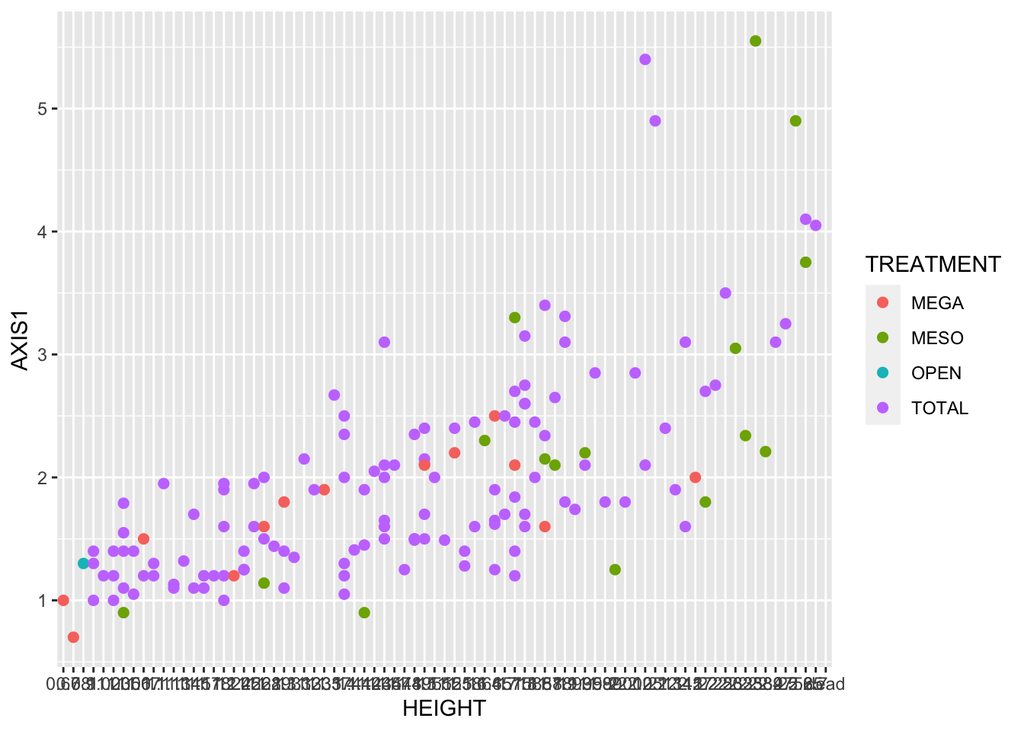

```r
library(ggplot2)
ggplot(data = acacia, mapping = aes(x = HEIGHT, y = AXIS1, color = TREATMENT)) +
geom_point(size = 2)
```

```r
labs(x ="Tree Height", y = "Tree Axis 1", title = "Acacia Trees Size Relationships")
```

```
## $x
## [1] "Tree Height"
##
## $y
## [1] "Tree Axis 1"
##
## $title
## [1] "Acacia Trees Size Relationships"
##
## attr(,"class")
## [1] "labels"
```

```r
colors()
```

[output not shown]

[output cut: 204 more lines]